# NLP_Learner_Notebook_Full_code_version

## Data Overview

The initial steps to get an overview of any dataset is to:

- Observe the first few rows of the dataset, to check whether the dataset has been loaded properly or not
- Get information about the number of rows and columns in the dataset
- Find out the data types of the columns to ensure that data is stored in the preferred format and the value of each property is as expected.

```python
# Display the head of the DataFrame
data.head()
```

|  | tweet_id | airline_sentiment | airline_sentiment_confidence | negativereason | negativereason_confidence | airline | airline_sentiment_gold | name | negativereason_gold | retweet_count | text | tweet_coord | tweet_created | tweet_location | user_timezone |
| --- | --- | --- | --- | --- | --- | --- | --- | --- | --- | --- | --- | --- | --- | --- | --- |
| 0 | 570306133677760513 | neutral | 1.0000 | NaN | NaN | Virgin America | NaN | cairdin | NaN | 0 | @VirginAmerica What @dhepburn said. | NaN | 2015-02-24 11:35:52 -0800 | NaN | Eastern Time (US & Canada) |
| 1 | 570301130888122368 | positive | 0.3486 | NaN | 0.0000 | Virgin America | NaN | jnardino | NaN | 0 | @VirginAmerica plus you've added commercials t... | NaN | 2015-02-24 11:15:59 -0800 | NaN | Pacific Time (US & Canada) |
| 2 | 570301083672813571 | neutral | 0.6837 | NaN | NaN | Virgin America | NaN | yvonnalynn | NaN | 0 | @VirginAmerica I didn't today... Must mean I n... | NaN | 2015-02-24 11:15:48 -0800 | Lets Play | Central Time (US & Canada) |
| 3 | 570301031407624196 | negative | 1.0000 | Bad Flight | 0.7033 | Virgin America | NaN | jnardino | NaN | 0 | @VirginAmerica it's really aggressive to blast... | NaN | 2015-02-24 11:15:36 -0800 | NaN | Pacific Time (US & Canada) |
| 4 | 570300817074462722 | negative | 1.0000 | Can't Tell | 1.0000 | Virgin America | NaN | jnardino | NaN | 0 | @VirginAmerica and it's a really big bad thing... | NaN | 2015-02-24 11:14:45 -0800 | NaN | Pacific Time (US & Canada) |

```python
# Display the tail of the DataFrame
data.tail()
```

|  | tweet_id | airline_sentiment | airline_sentiment_confidence | negativereason | negativereason_confidence | airline | airline_sentiment_gold | name | negativereason_gold | retweet_count | text | tweet_coord | tweet_created | tweet_location | user_timezone |
| --- | --- | --- | --- | --- | --- | --- | --- | --- | --- | --- | --- | --- | --- | --- | --- |
| 14635 | 569587686496825344 | positive | 0.3487 | NaN | 0.0000 | American | NaN | KristenReenders | NaN | 0 | @AmericanAir thank you we got on a different f... | NaN | 2015-02-22 12:01:01 -0800 | NaN | NaN |
| 14636 | 569587371693355008 | negative | 1.0000 | Customer Service Issue | 1.0000 | American | NaN | itsropes | NaN | 0 | @AmericanAir leaving over 20 minutes Late Flig... | NaN | 2015-02-22 11:59:46 -0800 | Texas | NaN |
| 14637 | 569587242672398336 | neutral | 1.0000 | NaN | NaN | American | NaN | sanyabun | NaN | 0 | @AmericanAir Please bring American Airlines to... | NaN | 2015-02-22 11:59:15 -0800 | Nigeria,lagos | NaN |
| 14638 | 569587188687634433 | negative | 1.0000 | Customer Service Issue | 0.6659 | American | NaN | SraJackson | NaN | 0 | @AmericanAir you have my money, you change my ... | NaN | 2015-02-22 11:59:02 -0800 | New Jersey | Eastern Time (US & Canada) |
| 14639 | 569587140490866689 | neutral | 0.6771 | NaN | 0.0000 | American | NaN | daviddtwu | NaN | 0 | @AmericanAir we have 8 ppl so we need 2 know h... | NaN | 2015-02-22 11:58:51 -0800 | dallas, TX | NaN |

```python
# Display information about the DataFrame structure
data.info()
```

```
<class 'pandas.core.frame.DataFrame'>
RangeIndex: 14640 entries, 0 to 14639
Data columns (total 15 columns):
 #   Column                        Non-Null Count  Dtype
---  ------                        --------------  -----
 0   tweet_id                      14640 non-null  int64
 1   airline_sentiment             14640 non-null  object
 2   airline_sentiment_confidence  14640 non-null  float64
 3   negativereason                9178 non-null   object
 4   negativereason_confidence     10522 non-null  float64
 5   airline                       14640 non-null  object
 6   airline_sentiment_gold        40 non-null     object
 7   name                          14640 non-null  object
 8   negativereason_gold           32 non-null     object
 9   retweet_count                 14640 non-null  int64
 10  text                          14640 non-null  object
 11  tweet_coord                   1019 non-null   object
 12  tweet_created                 14640 non-null  object
 13  tweet_location                9907 non-null   object
 14  user_timezone                 9820 non-null   object
dtypes: float64(2), int64(2), object(11)
memory usage: 1.7+ MB
```

### Observations

Size and Structure:

The dataset contains 14,640 entries (rows). It has 15 columns. Columns and Data Types:

- tweet_id: Integer data type.
- airline_sentiment: Categorical variable (object) indicating sentiment.
- airline_sentiment_confidence: Float representing confidence in sentiment prediction.

negativereason: Categorical variable (object) indicating the reason for negative sentiment (some missing values).

- negativereason_confidence: Float representing confidence in negative reason prediction (some missing values).
- airline: Categorical variable (object) indicating the airline.

= airline_sentiment_gold: Object (possibly categorical) with a low number of non-null entries.

- name: Object representing user names.
- negativereason_gold: Object indicating negative reason gold (some missing values).
- retweet_count: Integer representing the number of retweets.
- text: Object containing the tweet text.
- tweet_coord: Object containing tweet coordinates (some missing values).
- tweet_created: Object representing the timestamp of the tweet.
- tweet_location: Object indicating tweet location (some missing values).
- user_timezone: Object indicating user timezone (some missing values).

Missing Values:

There are missing values in columns like negativereason, negativereason_confidence, airline_sentiment_gold, negativereason_gold, tweet_coord, tweet_location, and user_timezone.

Data Types Summary:

2 columns with integer data type. 2 columns with float data type. 11 columns with object (categorical or string) data type.

```python
# Display the dimensions (number of rows and columns) of the DataFrame
data.shape
```

```
(14640, 15)
```

```python
# Check for missing values in each column and sum them up
data.isna().sum()
```

```
tweet_id                            0
airline_sentiment                   0
airline_sentiment_confidence        0
negativereason                   5462
negativereason_confidence        4118
airline                             0
airline_sentiment_gold          14600
name                                0
negativereason_gold             14608
retweet_count                       0
text                                0
tweet_coord                     13621
tweet_created                       0
tweet_location                   4733
user_timezone                    4820
dtype: int64
```

### Observations

Columns like airline_sentiment, airline_sentiment_confidence, airline, name, and retweet_count have no missing values.

Columns with a substantial number of missing values include:

- airline_sentiment_gold with 14,600 missing values out of 14,640.
- negativereason_gold with 14,608 missing values out of 14,640.
- tweet_coord with 13,621 missing values out of 14,640.

Columns with a moderate number of missing values include:

- negativereason with 5,462 missing values out of 14,640.
- negativereason_confidence with 4,118 missing values out of 14,640.
- tweet_location with 4,733 missing values out of 14,640.
- user_timezone with 4,820 missing values out of 14,640.

```python
# Check for duplicated rows in the DataFrame and sum them up
data.duplicated().sum()
```

```
36
```

```python
# Remove duplicated rows, keeping the first occurrence of each duplicated row
data = data.drop_duplicates(keep='first')

# Reset the index after removing duplicates and dropping the original index
data = data.reset_index(drop=True)
```

```python
# Check for duplicated rows in the DataFrame and sum them up
data.duplicated().sum()
```

```
0
```

```python
# Display the unique values in the 'airline_sentiment' column
data['airline_sentiment'].unique()
```

```
array(['neutral', 'positive', 'negative'], dtype=object)
```

## Exploratory Data Analysis

- EDA is an important part of any project involving data.
- It is important to investigate and understand the data better before building a model with it.
- A few questions have been mentioned below which will help you approach the analysis in the right manner and generate insights from the data.
- A thorough analysis of the data, in addition to the questions mentioned below, should be done.

**Questions**:

- What is the percentage of tweets for each airline?
- What is the distribution of sentiments across all the tweets?
- What is the distribution of sentiments for each airline?
- What does the plot of negative reasons indicate?
- How does a wordcloud appear for negative tweets?
- How does a wordcloud appear for positive tweets?
- What are insights observed from EDA?

```python
# function to create labeled barplots


def labeled_barplot(data, feature, perc=False, n=None):
    """
    Barplot with percentage at the top

    data: dataframe
    feature: dataframe column
    perc: whether to display percentages instead of count (default is False)
    n: displays the top n category levels (default is None, i.e., display all levels)
    """

    total = len(data[feature])  # length of the column
    count = data[feature].nunique()
    if n is None:
        plt.figure(figsize=(count + 1, 5))
    else:
        plt.figure(figsize=(n + 1, 5))

    plt.xticks(rotation=90, fontsize=15)
    ax = sns.countplot(
        data=data,
        x=feature,
        palette="Paired",
        order=data[feature].value_counts().index[:n].sort_values(),
    )

    for p in ax.patches:
        if perc == True:
            label = "{:.1f}%".format(
                100 * p.get_height() / total
            )  # percentage of each class of the category
        else:
            label = p.get_height()  # count of each level of the category

        x = p.get_x() + p.get_width() / 2  # width of the plot
        y = p.get_height()  # height of the plot

        ax.annotate(
            label,
            (x, y),
            ha="center",
            va="center",
            size=12,
            xytext=(0, 5),
            textcoords="offset points",
        )  # annotate the percentage

    plt.show()  # show the plot
```

What is the percentage of tweets for each airline?

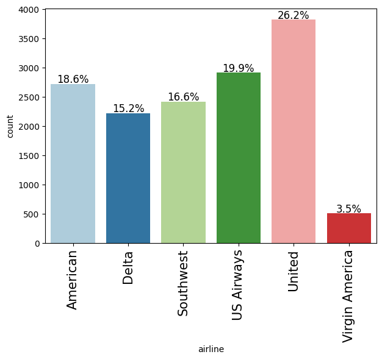

```python
labeled_barplot(data, "airline", perc=True)
```

### Observations

United Airlines Dominance:

United Airlines has the highest percentage of tweets at 26.2%. This suggests that a significant portion of the dataset is associated with United Airlines. US Airways and American Airlines:

US Airways and American Airlines also have substantial percentages at 19.9% and 18.6%, respectively. These airlines contribute significantly to the dataset. Southwest Airlines:

Southwest Airlines has a moderate representation with 16.6% of the tweets. Delta Airlines:

Delta Airlines has a slightly lower percentage at 15.2%, but it still represents a substantial portion of the dataset. Virgin Airlines:

Virgin Airlines has the lowest percentage at 3.5%, indicating a relatively smaller presence in the dataset.

What is the distribution of sentiments across all the tweets?

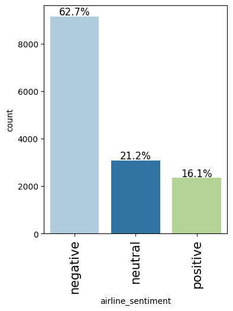

```python
labeled_barplot(data, "airline_sentiment", perc=True)
```

### Observations

Negative Sentiment Dominance:

The majority of tweets have a negative sentiment, accounting for 62.7% of the dataset. This indicates that a substantial portion of users expressing their opinions on Twitter about these airlines have negative sentiments. Neutral Sentiment:

About 21.2% of the tweets have a neutral sentiment. While not the majority, it still represents a significant proportion. Neutral sentiments could include factual statements, questions, or tweets that don't express a clear positive or negative opinion. Positive Sentiment:

Positive sentiments make up 16.1% of the dataset. While the lowest percentage, it's important to consider these tweets, as they reflect positive experiences or opinions about the airlines.

What is the distribution of sentiments for each airline?

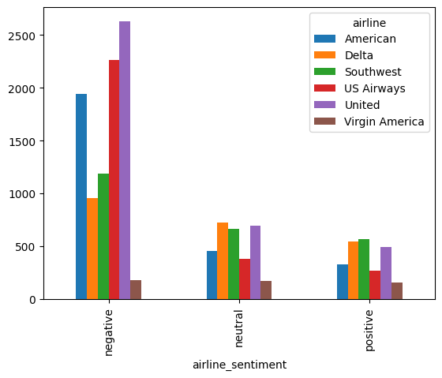

```python
# Group the data by 'airline_sentiment' and 'airline', then count the occurrences
airline_sentiment = data.groupby(['airline_sentiment', 'airline']).airline_sentiment.count().unstack()

# Plot a bar chart based on the grouped data
airline_sentiment.plot(kind='bar')
```

What does the plot of negative reasons indicate?

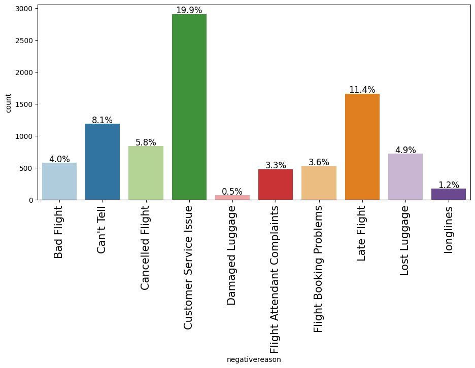

```python
labeled_barplot(data, "negativereason", perc=True)
```

```python
def plotBoW(cleaned_words):
    """
    Plot a word cloud based on Bag of Words.

    Parameters:
    - cleaned_words (str): Text data containing cleaned words.

    Returns:
    None
    """

    # Create a WordCloud object
    wordcloud = WordCloud(
        stopwords=STOPWORDS,       # Set stopwords for the word cloud
        colormap='RdBu',           # Set the color map
        background_color='white',  # Set the background color
        width=3000,                 # Set the width of the word cloud
        height=2500                 # Set the height of the word cloud
    ).generate(cleaned_words)

    # Create a figure and display the word cloud
    plt.figure(1, figsize=(12, 12))
    plt.imshow(wordcloud)
    plt.axis('off')  # Turn off the axis
    plt.show()
```

```python
# Filter the DataFrame to include only negative sentiment tweets
airline_tweets = data[data['airline_sentiment'] == 'negative']

# Combine all the text from the 'text' column into a single string
words = ' '.join(data['text'])

# Clean the text by removing URLs, mentions, and 'RT' (Retweet) tags
cleaned_word_negative = " ".join([word for word in words.split()
                                   if 'http' not in word
                                   and not word.startswith('@')
                                   and word != 'RT'])
```

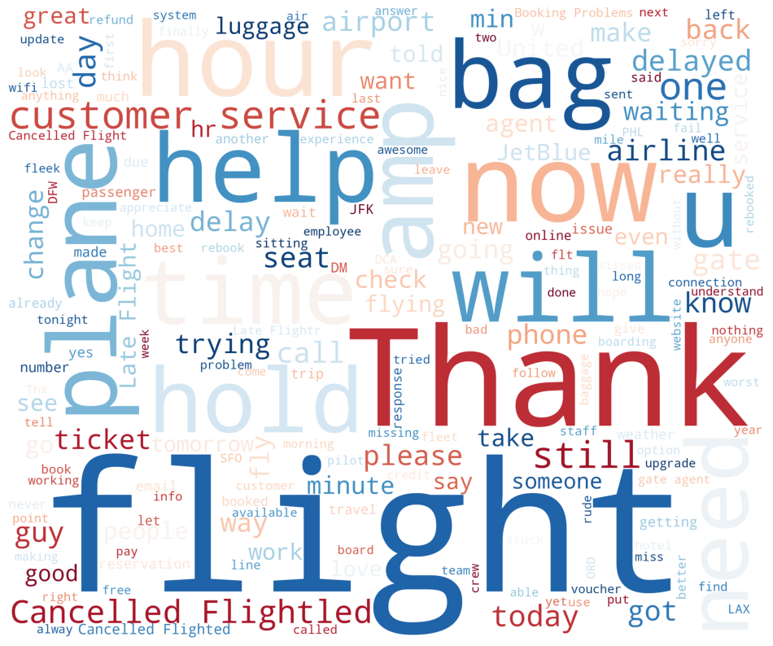

```python
# Plot a word cloud
plotBoW(cleaned_word_negative)
```

```python
# Filter the DataFrame to include only positive sentiment tweets
airline_tweets = data[data['airline_sentiment'] == 'positive']

# Combine all the text from the 'text' column into a single string
words = ' '.join(data['text'])

# Clean the text by removing URLs, mentions, and 'RT' (Retweet) tags
cleaned_word_positive = " ".join([word for word in words.split()
                                   if 'http' not in word
                                   and not word.startswith('@')
                                   and word != 'RT'])
```

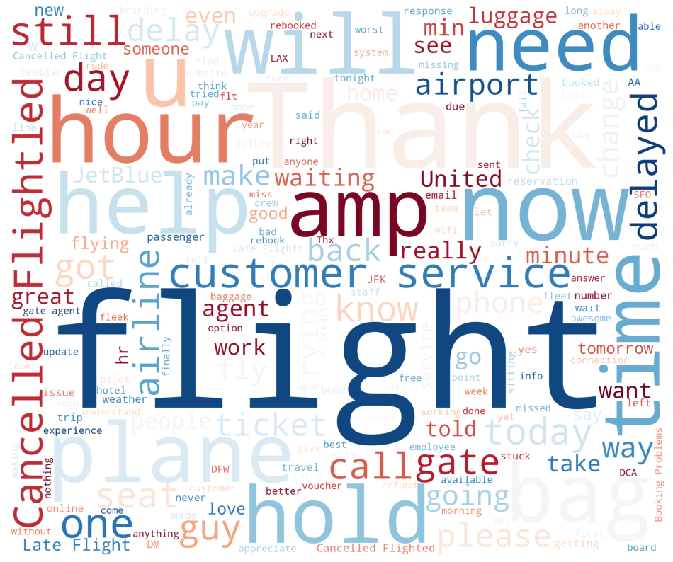

```python
# Plot a word cloud
plotBoW(cleaned_word_positive)
```

## Data Preparation for Modeling

- Drop all unnecessary columns
- Remove html tags
- Replace contractions in string(e.g. replace I'm --> I am) and so on.\
- Remove numbers
- Tokenization
- To remove Stopwords
- Lemmatized data

Drop all unnecessary columns

```python
# Select and keep only the 'text' and 'airline_sentiment' columns in the DataFrame
data = data[['text', 'airline_sentiment']]
```

Remove html tags

```python
# Define a function to strip HTML tags from text
def strip_html(text):
    """
    Strip HTML tags from the given text.

    Parameters:
    - text (str): Input text containing HTML tags.

    Returns:
    - str: Text with HTML tags removed.
    """
    soup = BeautifulSoup(text, "html.parser")
    return soup.get_text()

# Apply the strip_html function to the 'text' column of the DataFrame
data['text'] = data['text'].apply(strip_html)

# Display the head of the DataFrame after stripping HTML tags
data.head()
```

|  | text | airline_sentiment |
| --- | --- | --- |
| 0 | @VirginAmerica What @dhepburn said. | neutral |
| 1 | @VirginAmerica plus you've added commercials t... | positive |
| 2 | @VirginAmerica I didn't today... Must mean I n... | neutral |
| 3 | @VirginAmerica it's really aggressive to blast... | negative |
| 4 | @VirginAmerica and it's a really big bad thing... | negative |

Replace contractions in string(e.g. replace I'm --> I am) and so on.

```python
# Define a function to replace contractions in the text
def replace_contractions(text):
    """
    Replace contractions in the given text.

    Parameters:
    - text (str): Input text containing contractions.

    Returns:
    - str: Text with contractions replaced.
    """
    return contractions.fix(text)

# Apply the replace_contractions function to the 'text' column of the DataFrame
data['text'] = data['text'].apply(lambda x: replace_contractions(x))

# Display the head of the DataFrame after replacing contractions
data.head()
```

|  | text | airline_sentiment |
| --- | --- | --- |
| 0 | @VirginAmerica What @dhepburn said. | neutral |
| 1 | @VirginAmerica plus you have added commercials... | positive |
| 2 | @VirginAmerica I did not today... Must mean I ... | neutral |
| 3 | @VirginAmerica it is really aggressive to blas... | negative |
| 4 | @VirginAmerica and it is a really big bad thin... | negative |

Remove numbers

```python
# Define a function to remove numbers from the text
def remove_numbers(text):
    """
    Remove numerical digits from the given text.

    Parameters:
    - text (str): Input text containing numerical digits.

    Returns:
    - str: Text with numerical digits removed.
    """
    text = re.sub(r'\d+', '', text)
    return text

# Apply the remove_numbers function to the 'text' column of the DataFrame
data['text'] = data['text'].apply(remove_numbers)

# Display the head of the DataFrame after removing numbers from the 'text' column
data.head()
```

|  | text | airline_sentiment |
| --- | --- | --- |
| 0 | @VirginAmerica What @dhepburn said. | neutral |
| 1 | @VirginAmerica plus you have added commercials... | positive |
| 2 | @VirginAmerica I did not today... Must mean I ... | neutral |
| 3 | @VirginAmerica it is really aggressive to blas... | negative |
| 4 | @VirginAmerica and it is a really big bad thin... | negative |

Removing all the words that starts with '@'

```python
# Define a function to remove mentions (words starting with '@') from the text
def remove_mentions(text):
    """
    Remove mentions (words starting with '@') from the given text.

    Parameters:
    - text (str): Input text containing mentions.

    Returns:
    - str: Text with mentions removed.
    """
    text = re.sub(r'@\w+', '', text)
    return text

# Apply the remove_mentions function to the 'text' column of the DataFrame
data['text'] = data['text'].apply(remove_mentions)

# Display the head of the DataFrame after removing mentions from the 'text' column
data.head()
```

|  | text | airline_sentiment |
| --- | --- | --- |
| 0 | What said. | neutral |
| 1 | plus you have added commercials to the experi... | positive |
| 2 | I did not today... Must mean I need to take a... | neutral |
| 3 | it is really aggressive to blast obnoxious "e... | negative |
| 4 | and it is a really big bad thing about it | negative |

Tokenization

```python
# Apply nltk.word_tokenize to tokenize the 'text' column of the DataFrame
data['text'] = data.apply(lambda row: nltk.word_tokenize(row['text']), axis=1)

# Display the head of the DataFrame after tokenizing the 'text' column
data.head()
```

|  | text | airline_sentiment |
| --- | --- | --- |
| 0 | [What, said, .] | neutral |
| 1 | [plus, you, have, added, commercials, to, the,... | positive |
| 2 | [I, did, not, today, ..., Must, mean, I, need,... | neutral |
| 3 | [it, is, really, aggressive, to, blast, obnoxi... | negative |
| 4 | [and, it, is, a, really, big, bad, thing, abou... | negative |

To remove Stopwords

```python
# Get the list of English stopwords from nltk
stopwords = stopwords.words('english')

# Define a function to remove stopwords from a list of tokens
def remove_stopwords(tokens):
    """
    Remove stopwords from the given list of tokens.

    Parameters:
    - tokens (list): List of tokens.

    Returns:
    - list: List of tokens with stopwords removed.
    """
    return [token for token in tokens if token not in stopwords]

# Apply the remove_stopwords function to the 'text' column of the DataFrame
data['text'] = data['text'].apply(remove_stopwords)

# Display the head of the DataFrame after removing stopwords from the 'text' column
data.head()
```

|  | text | airline_sentiment |
| --- | --- | --- |
| 0 | [What, said, .] | neutral |
| 1 | [plus, added, commercials, experience, ..., ta... | positive |
| 2 | [I, today, ..., Must, mean, I, need, take, ano... | neutral |
| 3 | [really, aggressive, blast, obnoxious, ``, ent... | negative |
| 4 | [really, big, bad, thing] | negative |

Remove special characters

```python
# Define a function to remove emojis or special characters from a list of tokens
def remove_special_characters(tokens):
    # Define a regular expression pattern to match emojis or special characters
    pattern = r'[^\w\s]|\d'

    # Create a RegexpTokenizer with the defined pattern
    tokenizer = RegexpTokenizer(pattern)

    # Tokenize the list of tokens and filter out tokens that match the pattern
    filtered_tokens = [token for token in tokens if not tokenizer.tokenize(token)]

    # Return the filtered tokens
    return filtered_tokens


# Apply the remove_special_characters function to the 'text' column of the DataFrame
data['text'] = data['text'].apply(remove_special_characters)

# Display the head of the DataFrame after removing emojis or special characters from the 'text' column
data.head()
```

|  | text | airline_sentiment |
| --- | --- | --- |
| 0 | [What, said] | neutral |
| 1 | [plus, added, commercials, experience, tacky] | positive |
| 2 | [I, today, Must, mean, I, need, take, another,... | neutral |
| 3 | [really, aggressive, blast, obnoxious, enterta... | negative |
| 4 | [really, big, bad, thing] | negative |

Lower case

```python
# Define a function to remove emojis or special characters from a list of tokens
def to_lowercase(tokens):
  return [token.lower() for token in tokens]

# Apply the remove_special_characters function to the 'text' column of the DataFrame
data['text'] = data['text'].apply(to_lowercase)

# Display the head of the DataFrame after removing emojis or special characters from the 'text' column
data.head()
```

|  | text | airline_sentiment |
| --- | --- | --- |
| 0 | [what, said] | neutral |
| 1 | [plus, added, commercials, experience, tacky] | positive |
| 2 | [i, today, must, mean, i, need, take, another,... | neutral |
| 3 | [really, aggressive, blast, obnoxious, enterta... | negative |
| 4 | [really, big, bad, thing] | negative |

Lemmatized data

```python
# Create a WordNet Lemmatizer
lemmatizer = WordNetLemmatizer()

# Define a function to lemmatize a list of words
def lemmatize_list(words):
    """
    Lemmatize a list of words using WordNet Lemmatizer.

    Parameters:
    - words (list): List of words.

    Returns:
    - str: Lemmatized words joined into a string.
    """
    new_words = [lemmatizer.lemmatize(word, pos='v') for word in words]
    return ' '.join(new_words)

# Apply the lemmatize_list function to the 'text' column of the DataFrame
data['text'] = data['text'].apply(lemmatize_list)

# Display the head of the DataFrame after lemmatizing the 'text' column
data.head()
```

|  | text | airline_sentiment |
| --- | --- | --- |
| 0 | what say | neutral |
| 1 | plus add commercials experience tacky | positive |
| 2 | i today must mean i need take another trip | neutral |
| 3 | really aggressive blast obnoxious entertainmen... | negative |
| 4 | really big bad thing | negative |

## Model Building

```python
def metrics_score(actual, predicted):
    """
    Display a confusion matrix as a heatmap and provide metrics scores.

    Parameters:
    - actual (array-like): True labels.
    - predicted (array-like): Predicted labels.

    Returns:
    None
    """
    # Calculate confusion matrix
    cm = confusion_matrix(actual, predicted)

    # Plot the confusion matrix as a heatmap
    plt.figure(figsize=(8, 5))
    sns.heatmap(cm, annot=True, fmt='.2f', xticklabels=['negative', 'positive', 'neutral'], yticklabels=['negative', 'positive', 'neutral'])

    # Set labels and display the plot
    plt.ylabel('Actual')
    plt.xlabel('Predicted')
    plt.show()
```

### Using countvectorizer

- Intialize countvectorizer and use it for vectorization
- Store Independent and Dependent variables
- Split the data into train and test
- Build a Random Forest model on train data
- Use Cross validation to validate the score and to find optimal n_estimators
- Plot the misclassification error for each of estimators
- Test the model on testing data
- Plot the Confusion matrix

plot word cloud for top 20 important features obtained from Count vectorizer and random forest model

Intialize countvectorizer and use it for vectorization

```python
# Create a CountVectorizer with a maximum of 1000 features
Count_vec = CountVectorizer(max_features=1000)

# Transform the 'text' column using CountVectorizer
data_features = Count_vec.fit_transform(data['text'])

# Convert the sparse matrix to a dense array
data_features = data_features.toarray()

# Display the shape of the resulting array
data_features.shape
```

```
(14604, 1000)
```

Store Independent and Dependent variables

```python
# Features (X) are the transformed data from CountVectorizer
X = data_features

# Target variable (y) is the 'airline_sentiment' column
y = data['airline_sentiment']
```

Split the data into train and test

```python
# Split the data into training and testing sets
# - X_train and y_train are the features and labels for training
# - X_test and y_test are the features and labels for testing
# - test_size=0.25 specifies that 25% of the data will be used for testing
# - shuffle=False ensures that the data is not shuffled before splitting
X_train, X_test, y_train, y_test = train_test_split(X, y, test_size=0.25, shuffle=False)
```

Build a Random Forest model on train data

```python
# Create a RandomForestClassifier with 100 trees and 4 jobs (parallel processing)
cv_forest = RandomForestClassifier(n_estimators=100, n_jobs=4)

# Fit the RandomForestClassifier to the training data
cv_forest.fit(X_train, y_train)

# Display the details of the trained RandomForestClassifier
print(cv_forest)

# Perform cross-validation on the RandomForestClassifier and print the mean accuracy
cross_val_accuracy = np.mean(cross_val_score(cv_forest, X_train, y_train, cv=5, scoring='accuracy'))
print(f"Cross-Validation Mean Accuracy: {cross_val_accuracy}")
```

```
RandomForestClassifier(n_jobs=4)
Cross-Validation Mean Accuracy: 0.735417450800181
```

Use Cross validation to validate the score and to find optimal n_estimators

```python
# Initialize an empty list to store cross-validation scores
cv_scores = []

# Define a range of values for the number of estimators (trees)
n_estimators = list(range(100, 401, 50))

# Loop through each value of the number of estimators
for estimator in n_estimators:
    # Create a RandomForestClassifier with the current number of estimators
    cv_forest = RandomForestClassifier(n_estimators=estimator, n_jobs=4)

    # Perform cross-validation and append the mean accuracy to cv_scores
    scores = cross_val_score(cv_forest, X_train, y_train, cv=5, scoring='accuracy')
    cv_scores.append(scores.mean())

    # Print the number of estimators and the corresponding mean accuracy
    print(f"Estimator:{estimator}, Mean score: {scores.mean()}")
```

```
Estimator:100, Mean score: 0.7365125909438571
Estimator:150, Mean score: 0.7357823724701925
Estimator:200, Mean score: 0.7356000158389759
Estimator:250, Mean score: 0.736330025905062
Estimator:300, Mean score: 0.7365128827144671
Estimator:350, Mean score: 0.7347780980307569
Estimator:400, Mean score: 0.7368779294290257
```

### Observations

From these results, it seems that the mean accuracy fluctuates, and there isn't a clear trend of increasing or decreasing accuracy with the number of estimators. It's worth noting that the choice of the number of estimators might depend on various factors, and the highest mean accuracy doesn't necessarily correspond to the best model. Overfitting might occur with too many trees.

Plot the misclassification error for each of estimators

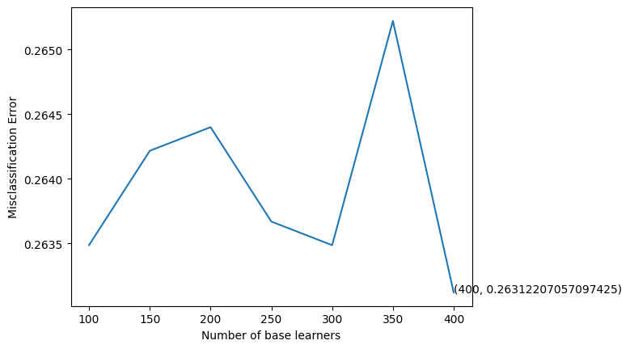

```python
# Calculate the error (misclassification error) for each number of estimators
error = [1 - x for x in cv_scores]

# Find the optimal number of estimators with the minimum error
optimal_learners = n_estimators[error.index(min(error))]

# Plot the misclassification error over the range of number of estimators
plt.plot(n_estimators, error)

# Annotate the plot with the optimal number of estimators and the corresponding error
xy = (optimal_learners, min(error))
plt.annotate('(%s, %s)' % xy, xy=xy, textcoords='data')

# Set labels for the axes
plt.xlabel("Number of base learners")
plt.ylabel("Misclassification Error")

# Display the plot
plt.show()
```

Test the model on testing data

```python
# Create a RandomForestClassifier with the optimal number of estimators
classifier_cv = RandomForestClassifier(n_estimators=400, n_jobs=4)

# Fit the RandomForestClassifier to the training data
classifier_cv.fit(X_train, y_train)

# Predict the labels for the test set
y_pred_cv = classifier_cv.predict(X_test)

# Display the predicted labels
y_pred_cv
```

```
array(['negative', 'negative', 'negative', ..., 'negative', 'negative',
       'negative'], dtype=object)
```

Plot the Confusion matrix plot word cloud for top 20 important features obtained from Count vectorizer and random forest model

[figure not shown]

```python
metrics_score(y_test, y_pred_cv)
```

```python
# Generate a classification report for the predicted labels
cr1 = {
    'name':'countvectorizer',
    'report':classification_report(y_test, y_pred_cv)
  }
# Print the classification report
print(cr1['report'])
```

```
              precision    recall  f1-score   support

    negative       0.86      0.88      0.87      2627
     neutral       0.50      0.47      0.48       574
    positive       0.64      0.63      0.63       450

    accuracy                           0.78      3651
   macro avg       0.67      0.66      0.66      3651
weighted avg       0.78      0.78      0.78      3651
```

### Observations

- The model performs well for negative sentiment, with high precision, recall, and F1-score.
- The model struggles more with neutral sentiment, as indicated by lower precision, recall, and F1-score.
- The positive sentiment shows a reasonable balance between precision and recall.

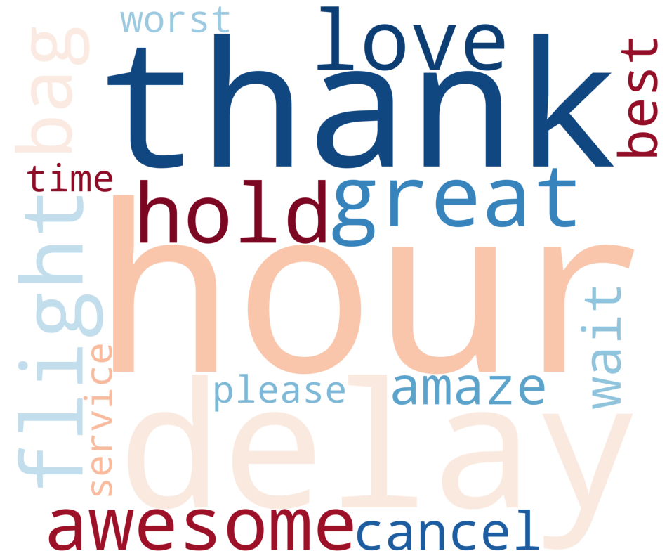

```python
# Get the names of all features from the CountVectorizer
all_features = Count_vec.get_feature_names_out()

# Initialize a string to store the top features
top_features = ''

# Get the feature importances from the trained classifier
feat = classifier_cv.feature_importances_

# Sort the features based on their importance in descending order
features = np.argsort(feat)[::-1]

# Concatenate the names of the top 20 features
for i in features[0:20]:
    top_features += all_features[i]
    top_features += ' '

# Plot a Word Cloud of the top features
plotBoW(top_features)
```

### Using TF-IDF (Term Frequency- Inverse Document Frequency)

- Intialize TFIDF and use it for vectorization
- Store Independent and Dependent variables
- Split the data into train and test
- Build a Random Forest model on train data
- Use Cross validation to validate the score and to find optimal n_estimators
- Plot the misclassification error for each of estimators
- Test the model on testing data
- Plot the Confusion matrix

plot word cloud for top 20 important features obtained from TFIDF and random forest model

Intialize TFIDF and use it for vectorization

```python
# Create a TfidfVectorizer with a maximum of 2000 features
vectorizer = TfidfVectorizer(max_features=2000)

# Transform the 'text' column using TfidfVectorizer
data_features = vectorizer.fit_transform(data['text'])

# Convert the sparse matrix to a dense array
data_features = data_features.toarray()

# Display the shape of the resulting array
data_features.shape
```

```
(14604, 2000)
```

Store Independent and Dependent variables

```python
# Features (X) are the transformed data from TfidfVectorizer
X = data_features

# Target variable (y) is the 'airline_sentiment' column
y = data['airline_sentiment']
```

Split the data into train and test

```python
# Split the data into training and testing sets
# - X_train and y_train are the features and labels for training
# - X_test and y_test are the features and labels for testing
# - test_size=0.25 specifies that 25% of the data will be used for testing
# - random_state=42 ensures reproducibility by fixing the random seed
X_train, X_test, y_train, y_test = train_test_split(X, y, test_size=0.25, random_state=42)
```

Build a Random Forest model on train data

```python
# Create a RandomForestClassifier with 100 trees and 4 jobs (parallel processing)
tfidf_forest = RandomForestClassifier(n_estimators=100, n_jobs=4)

# Fit the RandomForestClassifier to the training data
tfidf_forest.fit(X_train, y_train)

# Display the details of the trained RandomForestClassifier
print(tfidf_forest)

# Perform cross-validation on the RandomForestClassifier and print the mean accuracy
cross_val_accuracy_tfidf = np.mean(cross_val_score(tfidf_forest, X_train, y_train, cv=5, scoring='accuracy'))
print(f"Cross-Validation Mean Accuracy: {cross_val_accuracy_tfidf}")
```

```
RandomForestClassifier(n_jobs=4)
Cross-Validation Mean Accuracy: 0.7528537041320971
```

Use Cross validation to validate the score and to find optimal n_estimators

```python
# Initialize an empty list to store cross-validation scores for TF-IDF features
tfidf_scores = []

# Define a range of values for the number of estimators (trees)
n_estimators = list(range(20, 101, 20))

# Loop through each value of the number of estimators
for estimator in n_estimators:
    # Create a RandomForestClassifier with the current number of estimators
    tfidf_forest = RandomForestClassifier(n_estimators=estimator, n_jobs=4)

    # Perform cross-validation and append the mean accuracy to tfidf_scores
    scores = cross_val_score(tfidf_forest, X_train, y_train, cv=5, scoring='accuracy')
    tfidf_scores.append(scores.mean())

    # Print the number of estimators and the corresponding mean accuracy
    print(f"Estimator: {estimator}, Mean score: {scores.mean()}")
```

```
Estimator: 20, Mean score: 0.7452756711245048
Estimator: 40, Mean score: 0.7502059275283487
Estimator: 60, Mean score: 0.7498411725843999
Estimator: 80, Mean score: 0.75084511357171
Estimator: 100, Mean score: 0.7528542043102855
```

### Observations

These results suggest that the mean accuracy generally increases with the number of estimators, reaching its highest point at 100 estimators.

Plot the misclassification error for each of estimators

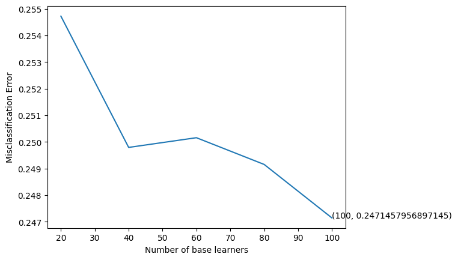

```python
# Calculate the error (misclassification error) for each number of estimators for TF-IDF features
error = [1 - x for x in tfidf_scores]

# Find the optimal number of estimators with the minimum error
optimal_learners_tfidf = n_estimators[error.index(min(error))]

# Plot the misclassification error over the range of number of estimators
plt.plot(n_estimators, error)

# Annotate the plot with the optimal number of estimators and the corresponding error
xy = (optimal_learners_tfidf, min(error))
plt.annotate('(%s, %s)' % xy, xy=xy, textcoords='data')

# Set labels for the axes
plt.xlabel("Number of base learners")
plt.ylabel("Misclassification Error")

# Display the plot
plt.show()
```

Test the model on testing data

```python
# Create a RandomForestClassifier with the optimal number of estimators for TF-IDF features
classifier_tfidf = RandomForestClassifier(n_estimators=100, n_jobs=4)

# Fit the RandomForestClassifier to the training data for TF-IDF features
classifier_tfidf.fit(X_train, y_train)

# Predict the labels for the test set using TF-IDF features
y_pred_tfidf = classifier_tfidf.predict(X_test)

# Display the predicted labels for TF-IDF features
y_pred_tfidf
```

```
array(['neutral', 'negative', 'negative', ..., 'negative', 'negative',
       'negative'], dtype=object)
```

Plot the Confusion matrix plot word cloud for top 20 important features obtained from TFIDF and random forest model

[figure not shown]

```python
metrics_score(y_test, y_pred_tfidf)
```

```python
# Generate a classification report for the predicted labels using TF-IDF features
cr2 = {
    'name': 'TF-IDF',
    'report':classification_report(y_test, y_pred_tfidf)
  }
# Print the classification report for TF-IDF features
print(cr2['report'])
```

```
              precision    recall  f1-score   support

    negative       0.81      0.92      0.86      2330
     neutral       0.62      0.46      0.53       741
    positive       0.73      0.59      0.65       580

    accuracy                           0.77      3651
   macro avg       0.72      0.65      0.68      3651
weighted avg       0.76      0.77      0.76      3651
```

### Observations

- The model performs well in terms of precision and recall for the negative class.
- The model struggles more with the neutral class, as indicated by lower precision, recall, and F1-score.
- The positive class shows a reasonable balance between precision and recall.

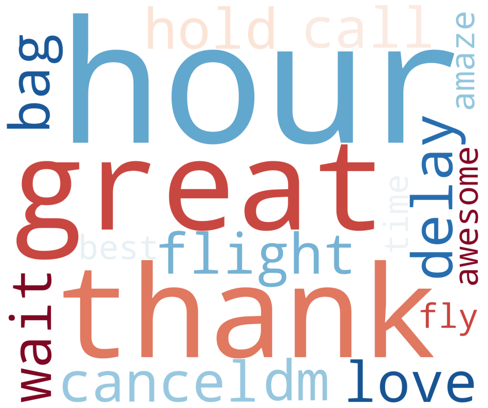

```python
# Get the names of all features from the TfidfVectorizer
all_features = vectorizer.get_feature_names_out()

# Initialize a string to store the top features for TF-IDF
top_features = ''

# Get the feature importances from the trained classifier for TF-IDF
feat = classifier_tfidf.feature_importances_

# Sort the features based on their importance in descending order for TF-IDF
features = np.argsort(feat)[::-1]

# Concatenate the names of the top 20 features for TF-IDF
for i in features[0:20]:
    top_features += all_features[i]
    top_features += ' '

# Plot a Word Cloud of the top features for TF-IDF
plotBoW(top_features)
```

### Using LSTM

```python
def graphs_and_report(history, predicted):
    # Plot training & validation loss values
    plt.plot(history.history['loss'])
    plt.plot(history.history['val_loss'])
    plt.title('Model loss')
    plt.ylabel('Loss')
    plt.xlabel('Epoch')
    plt.legend(['Train', 'Test'], loc='upper left')
    plt.show()

    # Plot training & validation accuracy values
    plt.plot(history.history['accuracy'])
    plt.plot(history.history['val_accuracy'])
    plt.title('Model accuracy')
    plt.ylabel('Accuracy')
    plt.xlabel('Epoch')
    plt.legend(['Train', 'Test'], loc='upper left')
    plt.show()
```

Tokenize the text column

```python
# Create a Tokenizer with a maximum vocabulary size of 800 words
tokenizer = Tokenizer(num_words=800, split=' ')

# Fit the Tokenizer on the 'text' column of the data
tokenizer.fit_on_texts(data['text'])
```

Encode the target variable

```python
# Convert the text data to sequences using the trained Tokenizer
X = tokenizer.texts_to_sequences(data['text'])

# Pad the sequences to ensure uniform length
X = pad_sequences(X)

print(X)
```

```
[[  0   0   0 ...   0  95  34]
 [  0   0   0 ... 420 211 107]
 [  0   0   0 ...  33  88 111]
 ...
 [  0   0   0 ... 365 354 167]
 [  0   0   0 ... 232   1  20]
 [  0   0   0 ...  68 109   2]]
```

Split the data into train and test

```python
# Create a LabelBinarizer to encode the categorical target variable
enc = LabelBinarizer()

# Fit the LabelBinarizer on the 'airline_sentiment' column and transform it to binary labels
y_encoded = enc.fit_transform(data['airline_sentiment'])

# Split the data into training and testing sets
# - X_train and y_train are the features and labels for training
# - X_test and y_test are the features and labels for testing
# - test_size=0.30 specifies that 30% of the data will be used for testing
# - random_state=42 ensures reproducibility by fixing the random seed
X_train, X_test, y_train, y_test = train_test_split(X, y_encoded, test_size=0.30, random_state=42)
```

Train the LSTM model

```python
# Create a Sequential model
model = Sequential()

# Add an Embedding layer with vocabulary size 800, embedding dimension 120, and input length determined by X.shape[1]
model.add(Embedding(800, 120, input_length=X.shape[1]))

# Add a SpatialDropout1D layer with dropout rate 0.2
model.add(SpatialDropout1D(0.2))

# Add an LSTM layer with 256 units, dropout rate 0.2, and recurrent dropout rate 0.2
model.add(LSTM(256, dropout=0.2, recurrent_dropout=0.2))

# Add a Dense layer with 124 units and ReLU activation function
model.add(Dense(124, activation='relu'))

# Add a Dropout layer with dropout rate 0.2
model.add(Dropout(0.2))

# Add another Dense layer with 64 units and ReLU activation function
model.add(Dense(64, activation='relu'))

# Add the output Dense layer with 3 units and softmax activation function for multi-class classification
model.add(Dense(3, activation='softmax'))

# Compile the model using categorical crossentropy loss, Adam optimizer, and accuracy as the metric
model.compile(loss='categorical_crossentropy', optimizer='adam', metrics=['accuracy'])

# Display a summary of the model architecture
model.summary()
```

```
Model: "sequential"
_________________________________________________________________
 Layer (type)                Output Shape              Param #
=================================================================
 embedding (Embedding)       (None, 24, 120)           96000

 spatial_dropout1d (Spatial  (None, 24, 120)           0
 Dropout1D)

 lstm (LSTM)                 (None, 256)               386048

 dense (Dense)               (None, 124)               31868

 dropout (Dropout)           (None, 124)               0

 dense_1 (Dense)             (None, 64)                8000

 dense_2 (Dense)             (None, 3)                 195

=================================================================
Total params: 522111 (1.99 MB)
Trainable params: 522111 (1.99 MB)
Non-trainable params: 0 (0.00 Byte)
_________________________________________________________________
```

```python
# Train the model using the training data
history = model.fit(X_train, y_train, epochs=10, batch_size=32, verbose='auto')
```

Test the model on train and test data

```python
# Make predictions on the test set using the trained LSTM model
y_pred_lstm = model.predict(X_test)

# Extract the class indices with the highest probability for each sample
y_pred_arg = np.argmax(y_pred_lstm, axis=1)

# Extract the class indices from the one-hot encoded true labels for each sample
y_test_arg = np.argmax(y_test, axis=1)

# Print the predicted class indices
print("Predicted Class Indices:")
print(y_pred_arg)

# Print the true class indices
print("\nTrue Class Indices:")
print(y_test_arg)
```

```
Predicted Class Indices:
[1 0 0 ... 0 0 0]

True Class Indices:
[1 0 0 ... 0 0 1]
```

```python
# Generate a classification report for the predicted class indices and true class indices
cr3 = {
    'name':'LSTM',
    'report':classification_report(y_test_arg, y_pred_arg)
  }
# Print the classification report
print(cr3['report'])
```

```
              precision    recall  f1-score   support

           0       0.85      0.86      0.85      2796
           1       0.58      0.54      0.56       885
           2       0.68      0.69      0.68       701

    accuracy                           0.77      4382
   macro avg       0.70      0.70      0.70      4382
weighted avg       0.77      0.77      0.77      4382
```

### Observations

- The model performs relatively well in terms of precision and recall for class 0.
- The model struggles more with class 1, as indicated by lower precision, recall, and F1-score.
- Class 2 shows a reasonable balance between precision and recall.

## Summary

```python
# Loop over the models (assumes you have cr1, cr2, cr3 defined)
for i in range(1, 4):

    # Use eval to retrieve the classification report for the current model
    cr = eval(f'cr{i}')

    print(f"Model {i} - {cr['name']}")

    # Print the classification report for the current model
    print(cr['report'])
```

```
Model 1 - countvectorizer
              precision    recall  f1-score   support

    negative       0.86      0.88      0.87      2627
     neutral       0.50      0.47      0.48       574
    positive       0.64      0.63      0.63       450

    accuracy                           0.78      3651
   macro avg       0.67      0.66      0.66      3651
weighted avg       0.78      0.78      0.78      3651

Model 2 - TF-IDF
              precision    recall  f1-score   support

    negative       0.81      0.92      0.86      2330
     neutral       0.62      0.46      0.53       741
    positive       0.73      0.59      0.65       580

    accuracy                           0.77      3651
   macro avg       0.72      0.65      0.68      3651
weighted avg       0.76      0.77      0.76      3651

Model 3 - LSTM
              precision    recall  f1-score   support

           0       0.85      0.86      0.85      2796
           1       0.58      0.54      0.56       885
           2       0.68      0.69      0.68       701

    accuracy                           0.77      4382
   macro avg       0.70      0.70      0.70      4382
weighted avg       0.77      0.77      0.77      4382
```

### Summary

Considerations:

- Computational Complexity:

  LSTM models are computationally more intensive compared to traditional machine learning models (like CountVectorizer and TF-IDF). Consider the computational resources available for training and inference.
- Interpretability:

  Traditional machine learning models (CountVectorizer, TF-IDF) are generally more interpretable. LSTM models might provide good performance but are often considered "black-box" models.

### Decision

If interpretability and computational efficiency are crucial, Model 1 or Model 2 might be preferred. If achieving the best possible performance is the primary goal and computational resources are available, Model 3 might be considered.

### Actionable Insights and Recommendations

The decision should align with the project requirements, considering the trade-offs between model complexity, interpretability, and performance.

It might be beneficial to explore further optimization, tuning, or ensembling methods depending on the specific nuances of the project.